# Capstone Project: Milestone Report

Max Kazakov

Saturday, July 25, 2015

## Synopsis

The purpose of this milestone report is to show the results of exploratory analysis performed on the text data and explain basic data transformations that make raw data clean and structured.

## Exploratory analysis

### Data

In linguistics, a corpus (plural corpora) is a large and structured set of texts. They are used to do statistical analysis. This project data corpora is provided by [http://www.corpora.heliohost.org/].

English corpora consists of three text files: **en_US.blogs.txt**, **en_US.news.txt**, **en_US.twitter.txt**. Each text file contains text samples obtained from different sources: blog posts, news articles and twitter users’ twits accordingly.

### Summary statistics

Each text corpus consists of different number of samples. Moreover even text samples greatly vary in length. The following summary explains the number of samples(lines) in each corpus, number of words, length of the longest line in words and average number of words in the line.

```
##              corpus line_cnt word_cnt max_line_words avg_line_words
## 1   en_US.blogs.txt   899288 37334441           6630             42
## 2    en_US.news.txt    77259  2643972           1031             34
## 3 en_US.twitter.txt  2360148 30373792             47             13
```

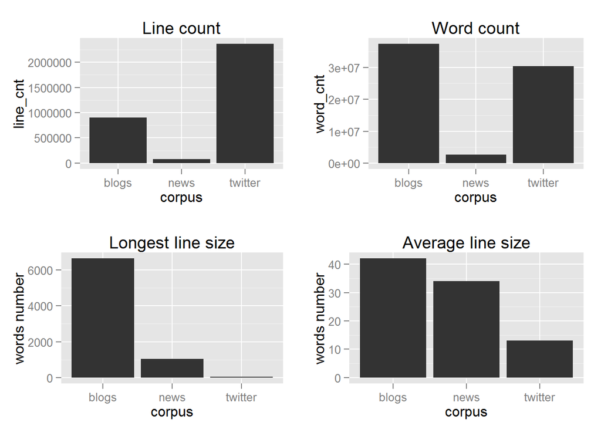

### Preprocessing

Natural language is unstructured, heterogeneous and often contains mistakes. Also natural language text contains words and symbols unimportant for this analysis. Therefore initial raw data requires number of transformation to make it clean and ready for further processsing, analysis and modelling. For example this is what raw twitter samples looks like:

```
## [1] "How are you? Btw thanks for the RT. You gonna be in DC anytime soon? Love to see you. Been way, way too long."
## [2] "When you meet someone special... you'll know. Your heart will beat more rapidly and you'll smile for no reason."
## [3] "they've decided its more fun if I don't."
```

As the result of these transformations data becomes tidy and ready for computer processing. For example this is how the same samples from twitter looks like now:

```
## [1] "how are you btw thanks for the rt you gonna be in dc anytime soon love to see you been way way too long"
## [2] "when you meet someone special you ll know your heart will beat more rapidly and you ll smile for no reason"
## [3] "they ve decided its more fun if i don t"
```

### Tokenization

In lexical analysis, tokenization is the process of breaking a stream of text up into words, phrases, symbols, or other meaningful elements called tokens. For this project tokens are distinct words and sequences of words called ngrams. Depending on the length of ngram it can be called also unigram(one word), bigram(2 words), trigram(3 words), etc.

For instance these are most frequent unigrams in corpora.

```
##       Docs
## Terms  en_US.blogs.txt en_US.news.txt en_US.twitter.txt
##   the           370090          30114            187609
##   and           217134          13510             86450
##   you            61085           1575            119321
##   for            72616           5373             76735
##   that           93683           5671             53355
##   with           57116           3971             34619
##   this           51292           1830             32612
##   was            56040           3453             23476
##   have           43354           2267             33725
##   are            38568           2044             31867
##   but            40503           2316             24665
##   not            34359           1720             24463
##   all            28656           1002             25127
##   your           19654            476             34118
##   just           20114            811             29701
```

### Tokens frequency

After the tokenization it’s possible to calculate tokens’ frequency and estimate it’s distribution. Following graph with log-log scale shows that tokens frequency distribution follow the Zipf’s law which states that given some corpus of natural language utterances, the frequency of any word is inversely proportional to its rank in the frequency table.

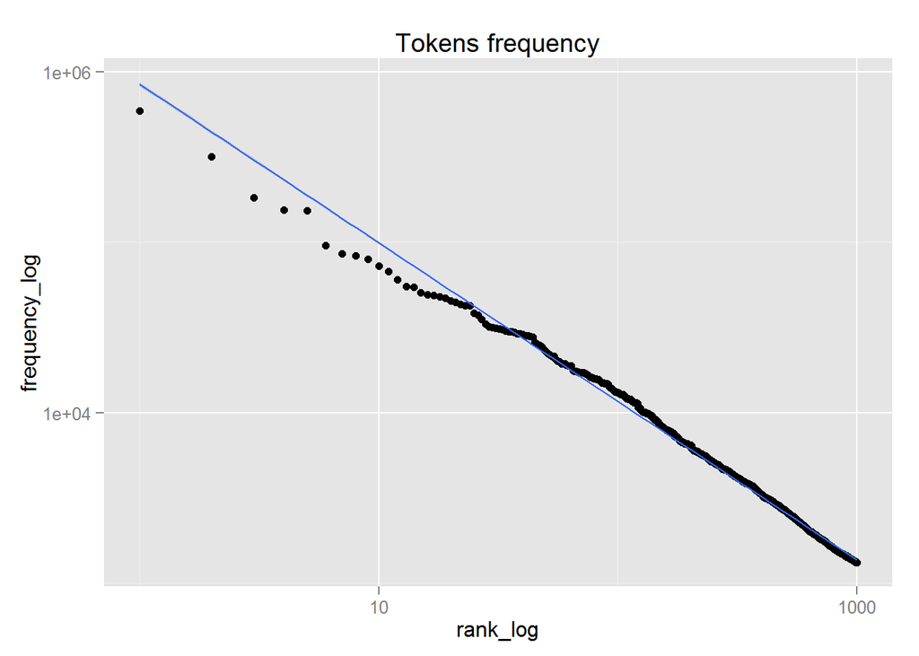

### Conclusion

The report covers brief exloratory analysis of the corpora data, including data analysis, cleaning process and summary statistics of it’s components. Also this report findings can be used for further prediction model development.